# Leaf-light-project

cong

2021/12/23

# 1 Background

The big light project puts a LED light into old-growth, secondary and man made forest(rubber tree forest) separetely, which shines at night. We rekon it as a long term disturbance to forest which has continued more than one year. Now we want to know whether this disturbance would effect the understory or not.

## 1.1 Our hypothesis

1. Prolong the light time may effect the nutrition circulation of understory
2. LED light attracts insects and insects dead may increase soil nitrogen, then effect the nutrition circulation of understory.

## 1.2 Place and species I choosed

We choose man made forest, for simulating the street tree and species Colocasia_gigantea and Melastoma_candidum

## 1.3 method

we punch leaf using leaf-disc to measure leaf nutrition.

# 2 Data Exploration

the pacakges we’ll use:

```r
library(kableExtra)
library(tidyverse)
library(lme4)
```

input our data

```r
llp <- read_csv("../data-raw/leaf_light_project.csv")
llp[1:5,] %>% kbl() %>% kable_styling()
```

| Plot | species | Distance | angel | individual | leaf ID | disc | disc_area | fresh_weight | dry_weight | canopy_openness |
| --- | --- | --- | --- | --- | --- | --- | --- | --- | --- | --- |
| 5 | Melastoma_candidum | 7.3 | 246 | 1 | 1 | 5 | 10 | 0.0469 | 0.0133 | 0.093571 |
| 5 | Melastoma_candidum | 7.3 | 246 | 1 | 2 | 5 | 10 | 0.0497 | 0.0140 | 0.093571 |
| 5 | Melastoma_candidum | 7.3 | 246 | 1 | 3 | 5 | 10 | 0.0476 | 0.0141 | 0.093571 |
| 5 | Melastoma_candidum | 7.3 | 246 | 1 | 4 | 5 | 10 | 0.0453 | 0.0140 | 0.093571 |
| 5 | Melastoma_candidum | 7.3 | 246 | 1 | 5 | 5 | 10 | 0.0489 | 0.0158 | 0.093571 |

Then we calculate LMA and show our samples location away from the light.

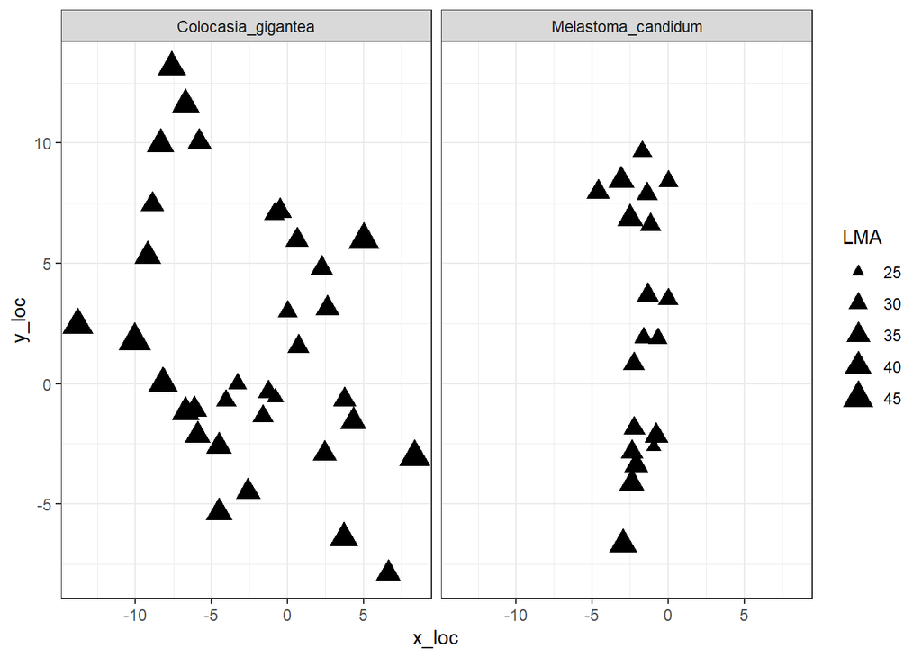

```r
llp1 <- llp |>mutate(LMA = dry_weight/(disc*pi*(0.005)^2))
llp1 |>
  mutate(x_loc = Distance*cos(angel*pi/180))|>
  mutate(y_loc = Distance*sin(angel*pi/180))|>
  ggplot(aes(x_loc, y_loc, size = LMA))+
  geom_point(shape =17)+
  facet_grid(cols = vars(species))+
  theme_bw()
```

(Notation: coordinate (0,0) is where the light is.)

Next, because we want to know whether light give an effect to understory, so we consider a graph between LMA and Distance away from the light which is on behalf of the gradient of light strength.

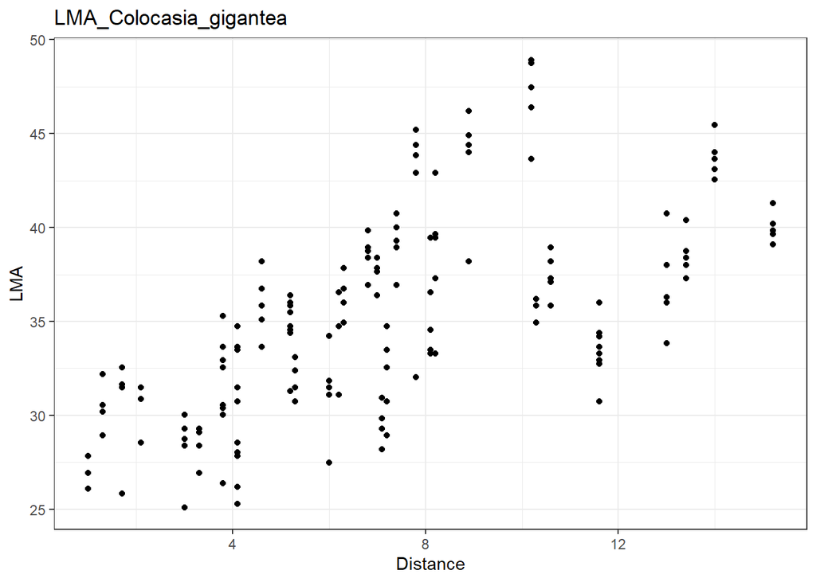

```r
llp1 |>
  filter(Plot == 2) |>
ggplot(aes(x = Distance, y = LMA))+
  geom_point()+
  labs(title = "LMA_Colocasia_gigantea")+
  theme_bw()
```

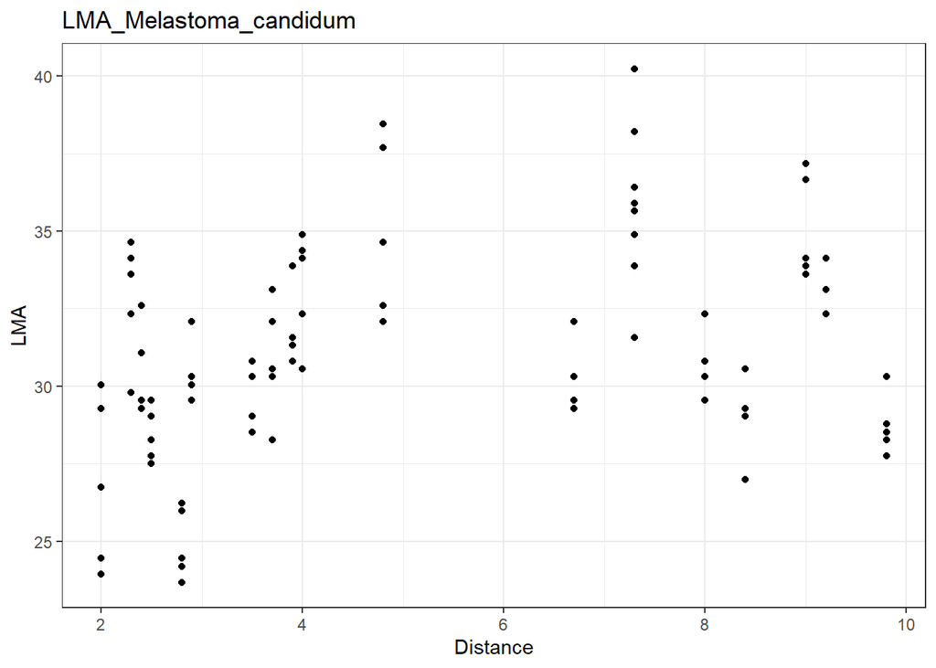

```r
llp1 |>
  filter(Plot == 5) |>
ggplot(aes(x = Distance, y = LMA))+
  geom_point()+
   labs(title = "LMA_Melastoma_candidum")+
  theme_bw()
```

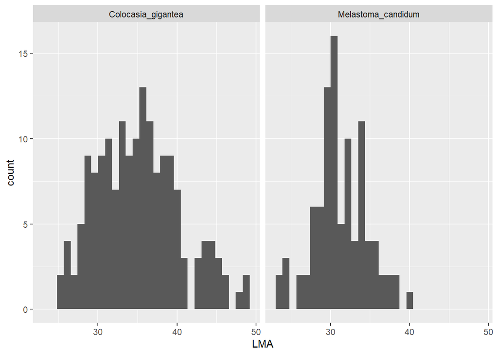

```r
llp1|>
  ggplot(aes(x = LMA))+
  facet_grid(cols = vars(species))+
  geom_histogram()
```

# 3 Data Mining

```r
mod <- lmer(data = llp1, formula = LMA ~ log(Distance)*log(canopy_openness)+(1|species))
summary(mod)
```

```
#> Linear mixed model fit by REML ['lmerMod']
#> Formula: LMA ~ log(Distance) * log(canopy_openness) + (1 | species)
#>    Data: llp1
#>
#> REML criterion at convergence: 1394.3
#>
#> Scaled residuals:
#>      Min       1Q   Median       3Q      Max
#> -2.75665 -0.75270  0.02021  0.62920  3.00758
#>
#> Random effects:
#>  Groups   Name        Variance Std.Dev.
#>  species  (Intercept)  4.657   2.158
#>  Residual             12.554   3.543
#> Number of obs: 260, groups:  species, 2
#>
#> Fixed effects:
#>                                    Estimate Std. Error t value
#> (Intercept)                          22.714      4.139   5.487
#> log(Distance)                        11.460      2.393   4.789
#> log(canopy_openness)                 -1.392      1.713  -0.812
#> log(Distance):log(canopy_openness)    2.836      1.039   2.731
#>
#> Correlation of Fixed Effects:
#>             (Intr) lg(Ds) lg(c_)
#> log(Distnc) -0.869
#> lg(cnpy_pn)  0.916 -0.924
#> lg(Dst):(_) -0.870  0.987 -0.950
```

# 4 stan

## 4.1 example

```r
library(rstan)
```

```r
library(bayesplot)
rstan::rstan_options(auto_write = TRUE)
options(mc.cores = parallel::detectCores()) # Run on multiple cores
```

Data for Melastoma_candidum

```r
sp1 <- llp1 |>
  filter(species == "Melastoma_candidum")

x <- cbind(1,
            log(1/(sp1$Distance)^2) |> scale(),
            scale(sp1$canopy_openness))

x <- cbind(x, x[,2] * x[,3])

list_d <- list(
  N = nrow(sp1),
  J = sp1$individual |> unique() |> length(),
  K = 4,
  ind = sp1$individual,
  x = x,
  y = log(sp1$LMA))
```

#### Mathematical model

Main likelihood functions:
$$y_{i,j} \sim \mathcal{N}(\mu_{i,j}, \sigma) \\
\mu_{i,j} = \boldsymbol{X} \cdot \boldsymbol{\beta} + \phi_j\\
\phi_j \sim \mathcal{N}(0, \tau)$$

where,

- $y_{i,j}$ is log(LMA) of leaf disc *i* of individual *j*,
- $\sigma$ is the standard deviation of the model,
- $\boldsymbol{X}$ is an $n \times 4$ matrix with intercepts, distance, canopy_openness and the interaction between distance and canopy_openness,
- $\boldsymbol{\beta}$ is a coefficient vector of size 4 (intercepts, distance, canopy_openness and the interaction between distance and canopy_openness),
- $\phi_j$ is the vayring intercept for individuals,
- $\tau$ is the scaling parameter for individual effects

Prior:

- we usually use weakly informative priors and we don’t use non-informative prirors such as unif(0, 1000).

$$\boldsymbol{\beta} \sim \mathcal{N}(0, 5) \\$$

Hyperprior:

- Half-cauchy works best for the scaling parameters for varying intercepts

$$\boldsymbol{\tau} \sim \text{Half-Caucy}(0, 2.5) \\$$

In reality, we use a lot of tricks to make the above model works better. For example, we do not try to fit the individual effects directly, but instead, we fit a latent Gaussian variable from which we can recover the individual effects.

$$\phi_j \sim \mathcal{N}(0, \tau)$$

cab be rewritten as:

$$\phi_j = \tau \cdot \tilde{\phi_j} \\
\tilde{\phi_j} \sim \mathcal{N}(0, 1) \\
\tau \sim \text{Half-cauchy}(0, 2.5)\\$$

A Half-cauchy distribution can be also represented using the tangent function and an uniform distribution:

$$\boldsymbol{\tau} = 2.5 \times tan(\boldsymbol{\tilde{\tau}}) \\
\boldsymbol{\tilde{\tau}} \sim \mathcal{U}(0, \pi / 2)$$

```r
model <- rstan::stan_model("../stan/model.stan")
```

```r
writeLines(readLines("../stan/model.stan"))
```

```
data{
  int<lower=0> N; // number of sample
  int<lower=1> J; // number of individual
  int<lower=1> K; // number of parameters
  matrix[N, K] x; // tree-level predictor
  vector[N] y; //log(LMA)
  int<lower=1,upper=J> ind[N]; // integer
}


parameters{
  matrix[K,1] beta;
  vector[J] phi_raw;
  real<lower=0,upper=pi()/2> tau_unif;
  real<lower=0> sigma;
}

transformed parameters{
  real<lower=0> tau;
  vector[J] phi;
  tau = 2.5 * tan(tau_unif); // implies tau ~ cauchy(0, 2.5)
  phi = phi_raw * tau;
}

model {
  //vector[N] mu;
  //for (n in 1:N) mu[n] = x[n, ] * beta + phi[ind[n]];
  phi_raw ~ std_normal();
  to_vector(beta) ~ normal(0, 5);
  y ~ normal(to_vector(x * beta) + phi[ind], sigma);
}
```

```r
fit <- rstan::sampling(model,
            data = list_d,
            verbose = TRUE,
            iter = 2000,
            warmup = 1000,
            thin = 1,
            chains = 4,
            refresh = 200,
            seed = 123)
```

```
#>
#> CHECKING DATA AND PREPROCESSING FOR MODEL 'model' NOW.
#>
#> COMPILING MODEL 'model' NOW.
#>
#> STARTING SAMPLER FOR MODEL 'model' NOW.
```

```r
summary(fit)$summary
```

```
#>                      mean      se_mean          sd          2.5%           25%
#> beta[1,1]    3.459415e+00 7.853398e-04 0.030530273   3.400709374   3.439755005
#> beta[2,1]   -4.217701e-02 8.895009e-04 0.035601825  -0.112851838  -0.064869256
#> beta[3,1]   -6.066213e-04 9.227563e-04 0.037315900  -0.076133762  -0.024549484
#> beta[4,1]   -3.083868e-02 6.313788e-04 0.026634990  -0.083572593  -0.048281005
#> phi_raw[1]   6.684914e-01 1.664479e-02 0.713349518  -0.756827727   0.191520685
#> phi_raw[2]   9.094645e-01 9.926824e-03 0.408960234   0.139765019   0.631546170
#> phi_raw[3]   4.588917e-01 1.601212e-02 0.632781780  -0.804461566   0.036797751
#> phi_raw[4]  -4.399054e-02 7.877831e-03 0.374580264  -0.780476272  -0.302218183
#> phi_raw[5]   1.169361e-01 8.087798e-03 0.383490651  -0.635332749  -0.131444116
#> phi_raw[6]  -1.649391e+00 1.338614e-02 0.569026117  -2.807049285  -2.017514902
#> phi_raw[7]   1.585166e+00 1.751336e-02 0.807104881   0.019132666   1.031307790
#> phi_raw[8]  -6.090502e-01 1.182087e-02 0.535483923  -1.642468384  -0.978791784
#> phi_raw[9]   2.194273e-01 1.266569e-02 0.522747700  -0.832486846  -0.128603272
#> phi_raw[10] -4.720144e-01 1.015264e-02 0.447495288  -1.334117775  -0.779435176
#> phi_raw[11] -3.662253e-01 8.371914e-03 0.371679664  -1.097309931  -0.611605487
#> phi_raw[12]  3.018512e-01 8.517681e-03 0.373659135  -0.411958781   0.044866642
#> phi_raw[13] -8.965657e-01 1.173896e-02 0.521534788  -1.920424495  -1.250224968
#> phi_raw[14]  7.402119e-01 9.727350e-03 0.434684793  -0.063503648   0.444242291
#> phi_raw[15] -5.413399e-01 9.301956e-03 0.426498219  -1.398656395  -0.832494995
#> phi_raw[16] -1.083221e+00 1.032768e-02 0.457129601  -1.997108614  -1.394973818
#> phi_raw[17]  1.160439e+00 1.391346e-02 0.625891867  -0.058789727   0.739203055
#> phi_raw[18]  3.529175e-01 9.923761e-03 0.469646899  -0.565044761   0.027482412
#> phi_raw[19] -8.918375e-01 1.301269e-02 0.581157935  -2.005837678  -1.294028332
#> tau_unif     3.937281e-02 2.605414e-04 0.008486024   0.026647742   0.033278082
#> sigma        5.429960e-02 9.485467e-05 0.004509095   0.046222650   0.051225495
#> tau          9.849056e-02 6.526393e-04 0.021258000   0.066635129   0.083225930
#> phi[1]       6.390834e-02 1.647767e-03 0.070519058  -0.077111914   0.018610719
#> phi[2]       8.667453e-02 8.652838e-04 0.037621220   0.014971126   0.061600457
#> phi[3]       4.380325e-02 1.603377e-03 0.062738376  -0.080983231   0.003154367
#> phi[4]      -3.961511e-03 7.816415e-04 0.036745247  -0.076656433  -0.028568320
#> phi[5]       1.117928e-02 8.082640e-04 0.037745253  -0.064328086  -0.012582282
#> phi[6]      -1.564174e-01 9.781927e-04 0.048742891  -0.254440532  -0.187173361
#> phi[7]       1.504259e-01 1.637569e-03 0.076152419   0.001611483   0.101117362
#> phi[8]      -5.776885e-02 1.121579e-03 0.052518027  -0.163906988  -0.091411678
#> phi[9]       2.090914e-02 1.293484e-03 0.052266795  -0.083749701  -0.012662683
#> phi[10]     -4.443222e-02 9.716910e-04 0.043447038  -0.128651018  -0.073126835
#> phi[11]     -3.442275e-02 7.994778e-04 0.035715209  -0.103112730  -0.057971242
#> phi[12]      2.884252e-02 8.368405e-04 0.036215285  -0.039175742   0.004344796
#> phi[13]     -8.478522e-02 1.074608e-03 0.048491380  -0.182592574  -0.115599688
```

[output cut: 39 more lines]

```
#> phi[6]      -1.546797e-01  -0.12476679  -0.061801998 2482.9831 1.0005970
#> phi[7]       1.500223e-01   0.19858448   0.303725474 2162.5590 1.0010141
#> phi[8]      -5.687883e-02  -0.02408947   0.045831163 2192.5898 1.0010408
#> phi[9]       2.099505e-02   0.05464485   0.126876129 1632.7882 1.0017405
#> phi[10]     -4.487422e-02  -0.01629578   0.042520795 1999.2358 1.0004984
#> phi[11]     -3.444885e-02  -0.01140790   0.034733153 1995.6921 1.0019295
#> phi[12]      2.942737e-02   0.05225277   0.099893093 1872.8302 1.0007509
#> phi[13]     -8.452041e-02  -0.05301994   0.009719547 2036.2404 1.0004532
#> phi[14]      6.930699e-02   0.09853478   0.150203556 2064.9530 1.0007749
#> phi[15]     -5.006007e-02  -0.02492949   0.026815864 2265.5410 1.0019455
#> phi[16]     -1.030092e-01  -0.07524773  -0.023696920 2385.9470 1.0012877
#> phi[17]      1.086331e-01   0.14897601   0.227382207 2171.7872 1.0000436
#> phi[18]      3.309196e-02   0.06381402   0.125281057 2222.4221 1.0001972
#> phi[19]     -8.503282e-02  -0.04675622   0.020114280 2108.2302 1.0002783
#> lp__         2.150419e+02 217.99342919 222.873066075  891.3578 1.0048836
```

95% CI

- beta[1,1] is the intercept which is not showing the figure.

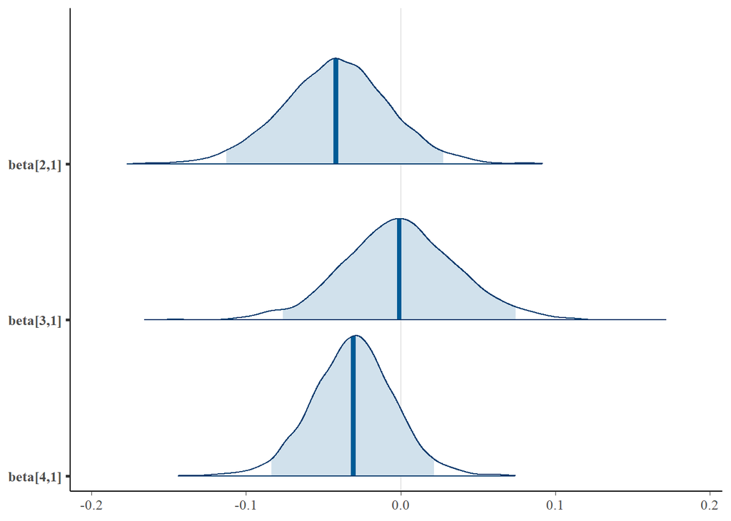

```r
beta_name <- paste0("beta[", 2:4, ",1]")
mcmc_areas(fit,
           pars = beta_name,
           prob = 0.95)
```

**NO EFECT!**

Data for Colocasia_gigantea

```r
sp2 <- llp1 |>
  filter(species == "Colocasia_gigantea")

x1 <- cbind(1,
           log(1/(sp2$Distance) ^2)|> scale(),
           scale(sp2$canopy_openness))

x1 <- cbind(x1, x1[,2] * x1[,3])

list_d <- list(
  N = nrow(sp2),
  J = sp2$individual |> unique() |> length(),
  K = 4,
  ind = sp2$individual,
  x = x1,
  y = log(sp2$LMA))
```

```r
model1 <- rstan::stan_model("../stan/model.stan")
```

```r
writeLines(readLines("../stan/model.stan"))
```

```
data{
  int<lower=0> N; // number of sample
  int<lower=1> J; // number of individual
  int<lower=1> K; // number of parameters
  matrix[N, K] x; // tree-level predictor
  vector[N] y; //log(LMA)
  int<lower=1,upper=J> ind[N]; // integer
}


parameters{
  matrix[K,1] beta;
  vector[J] phi_raw;
  real<lower=0,upper=pi()/2> tau_unif;
  real<lower=0> sigma;
}

transformed parameters{
  real<lower=0> tau;
  vector[J] phi;
  tau = 2.5 * tan(tau_unif); // implies tau ~ cauchy(0, 2.5)
  phi = phi_raw * tau;
}

model {
  //vector[N] mu;
  //for (n in 1:N) mu[n] = x[n, ] * beta + phi[ind[n]];
  phi_raw ~ std_normal();
  to_vector(beta) ~ normal(0, 5);
  y ~ normal(to_vector(x * beta) + phi[ind], sigma);
}
```

```r
fit1 <- rstan::sampling(model1,
                       data = list_d,
                       verbose = TRUE,
                       iter = 2000,
                       warmup = 1000,
                       thin = 1,
                       chains = 4,
                       refresh = 200,
                       seed = 123)
```

```
#>
#> CHECKING DATA AND PREPROCESSING FOR MODEL 'model' NOW.
#>
#> COMPILING MODEL 'model' NOW.
#>
#> STARTING SAMPLER FOR MODEL 'model' NOW.
```

```r
summary(fit1)$summary
```

```
#>                      mean      se_mean          sd          2.5%           25%
#> beta[1,1]     3.551391519 5.376012e-04 0.017458616   3.515889044  3.540520e+00
#> beta[2,1]    -0.104344079 6.332197e-04 0.021320624  -0.145763798 -1.189100e-01
#> beta[3,1]     0.049533548 6.897554e-04 0.022518089   0.005063399  3.432049e-02
#> beta[4,1]    -0.011957716 4.417596e-04 0.015659305  -0.042827858 -2.176306e-02
#> phi_raw[1]    0.699591918 1.134201e-02 0.554506126  -0.344208048  3.228900e-01
#> phi_raw[2]    0.324973707 1.094525e-02 0.496455291  -0.669034824 -7.404382e-03
#> phi_raw[3]   -0.276551415 1.099761e-02 0.529131297  -1.311322946 -6.275432e-01
#> phi_raw[4]   -0.031491326 1.639461e-02 0.814279468  -1.627836474 -5.838141e-01
#> phi_raw[5]   -1.260930583 1.169365e-02 0.454407390  -2.177003906 -1.550213e+00
#> phi_raw[6]   -0.842655073 1.050027e-02 0.446960304  -1.719985237 -1.144829e+00
#> phi_raw[7]   -1.401290254 1.368088e-02 0.549536548  -2.471333746 -1.769725e+00
#> phi_raw[8]   -0.587762952 9.320389e-03 0.409373244  -1.399255006 -8.674027e-01
#> phi_raw[9]   -0.987648322 1.510734e-02 0.553423986  -2.071983260 -1.364338e+00
#> phi_raw[10]  -0.720335117 8.364697e-03 0.400973259  -1.507262293 -9.897081e-01
#> phi_raw[11]   1.423210652 8.321207e-03 0.386608026   0.694826946  1.151029e+00
#> phi_raw[12]  -0.871170933 1.268835e-02 0.504646618  -1.870667391 -1.205162e+00
#> phi_raw[13]  -0.574040660 1.457756e-02 0.532867874  -1.613431463 -9.394422e-01
#> phi_raw[14]   1.100276083 1.163716e-02 0.492474543   0.160823623  7.684129e-01
#> phi_raw[15]   0.789587370 1.039887e-02 0.455030310  -0.098412285  4.814152e-01
#> phi_raw[16]   0.701940151 7.143924e-03 0.365751211   0.011337286  4.582888e-01
#> phi_raw[17]   0.463558298 7.097726e-03 0.372788861  -0.247654318  2.117034e-01
#> phi_raw[18]  -0.202381545 6.966059e-03 0.392731861  -1.002077345 -4.572065e-01
#> phi_raw[19]   0.800195018 7.306029e-03 0.374817060   0.111596427  5.453684e-01
#> phi_raw[20]   0.425647139 7.304931e-03 0.371343955  -0.266293696  1.647563e-01
#> phi_raw[21]  -0.376053482 8.013846e-03 0.372671634  -1.116453903 -6.226209e-01
#> phi_raw[22]   2.107829381 1.142668e-02 0.463517075   1.260313296  1.780679e+00
#> phi_raw[23]  -0.167484302 8.121748e-03 0.395946777  -0.969485210 -4.294159e-01
#> phi_raw[24]  -1.451797879 9.689083e-03 0.467155814  -2.392664165 -1.755272e+00
#> phi_raw[25]   0.844564444 1.037982e-02 0.440084620  -0.004448025  5.434343e-01
#> phi_raw[26]  -1.142078744 1.073524e-02 0.465069776  -2.081559034 -1.449243e+00
#> phi_raw[27]  -0.747486599 9.226300e-03 0.424151937  -1.583113826 -1.030400e+00
#> phi_raw[28]  -0.488616686 9.495459e-03 0.440745336  -1.349014948 -7.839176e-01
#> phi_raw[29]  -0.446917001 1.108846e-02 0.476830320  -1.386614536 -7.580102e-01
#> phi_raw[30]  -0.035987135 9.283643e-03 0.404899426  -0.848720767 -3.030314e-01
#> phi_raw[31]   0.937098106 7.674587e-03 0.375322700   0.218462458  6.936933e-01
#> phi_raw[32]   0.753998850 9.175108e-03 0.401571505  -0.020811736  4.879268e-01
#> phi_raw[33]   0.104764656 1.021159e-02 0.416396834  -0.724245299 -1.751225e-01
#> phi_raw[34]   1.312013965 1.091468e-02 0.436670304   0.486846505  1.016193e+00
#> phi_raw[35]  -0.071820255 1.183941e-02 0.492917271  -1.027714429 -3.991602e-01
```

[output cut: 103 more lines]

```
#> phi[22]       0.185867245   0.209800766   0.254462958 2314.5875 1.0023651
#> phi[23]      -0.014184347   0.009026518   0.053100806 2317.7511 1.0005492
#> phi[24]      -0.128143370  -0.102178885  -0.051025492 2459.8564 1.0003827
#> phi[25]       0.074024515   0.099213663   0.151458572 1940.9047 1.0023656
#> phi[26]      -0.099654583  -0.073738215  -0.024611373 1900.5666 1.0004700
#> phi[27]      -0.065556165  -0.041110320   0.005725060 2044.9465 1.0020240
#> phi[28]      -0.042541503  -0.017499160   0.032945274 2075.1731 1.0030915
#> phi[29]      -0.039117325  -0.012095313   0.044393338 1756.2414 1.0039358
#> phi[30]      -0.002559186   0.020382431   0.068860357 1846.6802 1.0020050
#> phi[31]       0.081693565   0.104024215   0.146253575 2604.0815 1.0007208
#> phi[32]       0.066197558   0.089348542   0.135034991 2010.0408 1.0030812
#> phi[33]       0.010007552   0.034043178   0.080988712 1627.7100 1.0018832
#> phi[34]       0.115541826   0.139269577   0.189050774 1826.3911 1.0061915
#> phi[35]      -0.006193792   0.022690490   0.079580074 1715.9313 1.0009852
#> lp__        344.087949600 348.326915839 355.203139067  770.3826 1.0042396
```

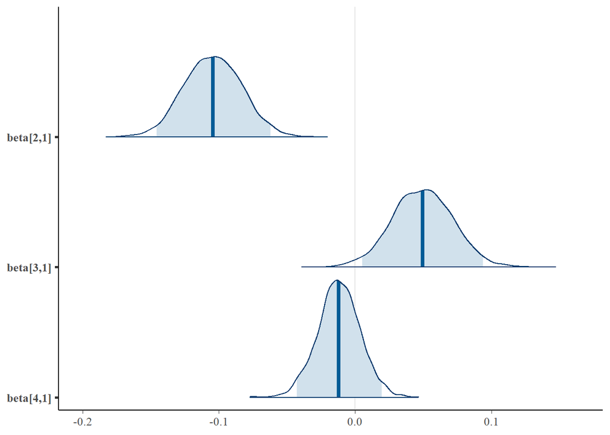

```r
beta_name <- paste0("beta[", 2:4, ",1]")
mcmc_areas(fit1,
           pars = beta_name,
           prob = 0.95)
```

So we can see for species Colocasia_gigantea the regression coefficients of distance and canopy openness are significant.

# 5 Table the results

For species one “Melastoma_candidum”, coefficients table.

```r
test <- summary(fit)$summary[2:4,] |> as_tibble()

quantile_interval <-  paste0("[",round(test$`2.5%`,4),", ",  round(test$`97.5%`,4),"]")

table_sp1 <- data.frame(
  "Parameters" = c(
                   "ALAN's effect",
                   "Daylight's effect",
                   "interaction"),
  "mean_value" = round(test$mean,4),
 quantile_interval
)

table_sp1 %>%
  kbl(caption = "Coefficients table of species Melastoma_candidum") %>%column_spec(3,bold =  ifelse(test$`2.5%`*test$`97.5%`>0, "T","F"))%>%
  kable_classic(full_width = F, html_font = "Cambria")
```

Coefficients table of species Melastoma_candidum

| Parameters | mean_value | quantile_interval |
| --- | --- | --- |
| ALAN’s effect | -0.0422 | [-0.1129, 0.0276] |
| Daylight’s effect | -0.0006 | [-0.0761, 0.0744] |
| interaction | -0.0308 | [-0.0836, 0.0216] |

For species “Colocasia_gigantea”, coefficients table.

```r
test1 <- summary(fit1)$summary[2:4,] |> as_tibble()

quantile_interval <-  paste0("[",round(test1$`2.5%`,4),", ",  round(test1$`97.5%`,4),"]")

table_sp2 <- data.frame(
  "Parameters" = c(
                   "ALAN's effect",
                   "Daylight's effect",
                   "interaction"),
  "mean_value" = round(test1$mean,4),
 quantile_interval
)

table_sp2 %>%
  kbl(caption = "Coefficients table of species Colocasia_gigantea") %>%column_spec(3,bold =  ifelse(test1$`2.5%`*test1$`97.5%`>0, "T","F"))%>%
  kable_classic(full_width = F, html_font = "Cambria")
```

Coefficients table of species Colocasia_gigantea

| Parameters | mean_value | quantile_interval |
| --- | --- | --- |
| ALAN’s effect | -0.1043 | [-0.1458, -0.0621] |
| Daylight’s effect | 0.0495 | [0.0051, 0.0938] |
| interaction | -0.0120 | [-0.0428, 0.0195] |

#Put together

```r
rbind(table_sp1,table_sp2)|>
  kbl( caption = "Coefficients table") %>%
  kable_paper("striped", full_width = F) %>%
  column_spec(3,bold =c(ifelse(test$`2.5%`*test$`97.5%`>0, "T","F"),       ifelse(test1$`2.5%`*test1$`97.5%`>0, "T","F"))) %>%
  pack_rows("Melastoma_candidum", 1, 3) %>%
  pack_rows("Colocasia_gigantea", 4, 6)
```

Coefficients table

| Parameters | mean_value | quantile_interval |
| --- | --- | --- |
| **Melastoma_candidum** |  |  |
| ALAN’s effect | -0.0422 | [-0.1129, 0.0276] |
| Daylight’s effect | -0.0006 | [-0.0761, 0.0744] |
| interaction | -0.0308 | [-0.0836, 0.0216] |
| **Colocasia_gigantea** |  |  |
| ALAN’s effect | -0.1043 | [-0.1458, -0.0621] |
| Daylight’s effect | 0.0495 | [0.0051, 0.0938] |
| interaction | -0.0120 | [-0.0428, 0.0195] |